# Final Project

GROUP-5 (Devansh Patel, Moyuri Sarkar, Rajeev Tripathi)

# Introduction

[figure not shown]

##### Regork has made significant progress in the grocery market but continues to face challenges in maintaining customer loyalty and stabilizing revenue. Key questions remain: How can we increase revenue and address its fluctuations? These are critical for Regork’s growth. To overcome these challenges, it’s essential to allocate resources efficiently by optimizing marketing campaigns and focusing on specific demographics that exhibit unusual shopping behaviors to boost customer retention and spending.

##### In our analysis, we examined internal data, including marketing campaigns, coupon redemptions, and customer demographics, by merging datasets, segmenting income groups, assessing campaign performance, and identifying areas for improvement. The findings indicate that Type A campaigns are highly effective and should be expanded. Meanwhile, Type B and C campaigns could be optimized by shortening their duration and aligning with peak shopping periods. Additionally, there’s an opportunity to engage higher-income groups (e.g., $100K–$125K and $200K–$250K) with more personalized offers, which could drive further revenue growth.

##### Implementing these strategies will enhance revenue, optimize resource allocation, and improve customer loyalty through targeted campaigns. We recommend considering these adjustments to position Regork for sustained growth and a stronger market share.

# Packages Required

##### The following R packages are required in order to run the code in this R project:

```r
library(completejourney)
library(tidyverse)
library(RColorBrewer) #Provides color palettes for data visualization
library(scales) #Tools for scaling and formatting data visualizations
library(ggrepel) #Enhances ggplot2 by avoiding overlapping text labels in plots
library(stringr) #Simplifies string manipulation and regular expressions
```

# Data Preparation

##### The data for this R project is sourced from the [CompleteJourney](https://uc.instructure.com/courses/1730798/assignments/21314876?module_item_id=73091181) package, which offers datasets derived from grocery shopping transactions of 2,469 households. The datasets encompass various entities such as demographics, products, coupons, and campaigns, collected over a one-year period spanning from January to December 2017. More information on the datasets can be found on the [CompleteJourney](https://cran.r-project.org/web/packages/completejourney/vignettes/completejourney.html) website.

**Let’s Begin**

##### The first step in the data preparation process is to retrieve the necessary datasets.

```r
transactions <- get_transactions()
promotions <- get_promotions()
str(transactions)
```

```
## tibble [1,469,307 × 11] (S3: tbl_df/tbl/data.frame)
##  $ household_id         : chr [1:1469307] "900" "900" "1228" "906" ...
##  $ store_id             : chr [1:1469307] "330" "330" "406" "319" ...
##  $ basket_id            : chr [1:1469307] "31198570044" "31198570047" "31198655051" "31198705046" ...
##  $ product_id           : chr [1:1469307] "1095275" "9878513" "1041453" "1020156" ...
##  $ quantity             : num [1:1469307] 1 1 1 1 2 1 1 1 1 1 ...
##  $ sales_value          : num [1:1469307] 0.5 0.99 1.43 1.5 2.78 5.49 1.5 1.88 1.5 2.69 ...
##  $ retail_disc          : num [1:1469307] 0 0.1 0.15 0.29 0.8 0.5 0.29 0.21 1.29 0 ...
##  $ coupon_disc          : num [1:1469307] 0 0 0 0 0 0 0 0 0 0 ...
##  $ coupon_match_disc    : num [1:1469307] 0 0 0 0 0 0 0 0 0 0 ...
##  $ week                 : int [1:1469307] 1 1 1 1 1 1 1 1 1 1 ...
##  $ transaction_timestamp: POSIXct[1:1469307], format: "2017-01-01 06:53:26" "2017-01-01 07:10:28" ...
```

```r
products
```

```
## # A tibble: 92,331 × 7
##    product_id manufacturer_id department    brand  product_category product_type
##    <chr>      <chr>           <chr>         <fct>  <chr>            <chr>
##  1 25671      2               GROCERY       Natio… FRZN ICE         ICE - CRUSH…
##  2 26081      2               MISCELLANEOUS Natio… <NA>             <NA>
##  3 26093      69              PASTRY        Priva… BREAD            BREAD:ITALI…
##  4 26190      69              GROCERY       Priva… FRUIT - SHELF S… APPLE SAUCE
##  5 26355      69              GROCERY       Priva… COOKIES/CONES    SPECIALTY C…
##  6 26426      69              GROCERY       Priva… SPICES & EXTRAC… SPICES & SE…
##  7 26540      69              GROCERY       Priva… COOKIES/CONES    TRAY PACK/C…
##  8 26601      69              DRUG GM       Priva… VITAMINS         VITAMIN - M…
##  9 26636      69              PASTRY        Priva… BREAKFAST SWEETS SW GDS: SW …
## 10 26691      16              GROCERY       Priva… PNT BTR/JELLY/J… HONEY
## # ℹ 92,321 more rows
## # ℹ 1 more variable: package_size <chr>
```

```r
demographics
```

```
## # A tibble: 801 × 8
##    household_id age   income    home_ownership marital_status household_size
##    <chr>        <ord> <ord>     <ord>          <ord>          <ord>
##  1 1            65+   35-49K    Homeowner      Married        2
##  2 1001         45-54 50-74K    Homeowner      Unmarried      1
##  3 1003         35-44 25-34K    <NA>           Unmarried      1
##  4 1004         25-34 15-24K    <NA>           Unmarried      1
##  5 101          45-54 Under 15K Homeowner      Married        4
##  6 1012         35-44 35-49K    <NA>           Married        5+
##  7 1014         45-54 15-24K    <NA>           Married        4
##  8 1015         45-54 50-74K    Homeowner      Unmarried      1
##  9 1018         45-54 35-49K    Homeowner      Married        5+
## 10 1020         45-54 25-34K    Homeowner      Married        2
## # ℹ 791 more rows
## # ℹ 2 more variables: household_comp <ord>, kids_count <ord>
```

```r
coupon_redemptions
```

```
## # A tibble: 2,102 × 4
##    household_id coupon_upc  campaign_id redemption_date
##    <chr>        <chr>       <chr>       <date>
##  1 1029         51380041013 26          2017-01-01
##  2 1029         51380041313 26          2017-01-01
##  3 165          53377610033 26          2017-01-03
##  4 712          51380041013 26          2017-01-07
##  5 712          54300016033 26          2017-01-07
##  6 2488         51200092776 26          2017-01-10
##  7 2488         51410010050 26          2017-01-10
##  8 1923         53000012033 26          2017-01-14
##  9 1923         54300021057 26          2017-01-14
## 10 1923         57047091041 26          2017-01-14
## # ℹ 2,092 more rows
```

```r
coupons
```

```
## # A tibble: 116,204 × 3
##    coupon_upc  product_id campaign_id
##    <chr>       <chr>      <chr>
##  1 10000085207 9676830    26
##  2 10000085207 9676943    26
##  3 10000085207 9676944    26
##  4 10000085207 9676947    26
##  5 10000085207 9677008    26
##  6 10000085207 9677052    26
##  7 10000085207 9677385    26
##  8 10000085207 9677479    26
##  9 10000085207 9677791    26
## 10 10000085207 9677878    26
## # ℹ 116,194 more rows
```

```r
campaigns
```

```
## # A tibble: 6,589 × 2
##    campaign_id household_id
##    <chr>       <chr>
##  1 1           105
##  2 1           1238
##  3 1           1258
##  4 1           1483
##  5 1           2200
##  6 1           293
##  7 1           529
##  8 1           536
##  9 1           568
## 10 1           630
## # ℹ 6,579 more rows
```

```r
campaign_descriptions
```

```
## # A tibble: 27 × 4
##    campaign_id campaign_type start_date end_date
##    <chr>       <ord>         <date>     <date>
##  1 1           Type B        2017-03-03 2017-04-09
##  2 2           Type B        2017-03-08 2017-04-09
##  3 3           Type C        2017-03-13 2017-05-08
##  4 4           Type B        2017-03-29 2017-04-30
##  5 5           Type B        2017-04-03 2017-05-07
##  6 6           Type C        2017-04-19 2017-05-21
##  7 7           Type B        2017-04-24 2017-05-28
##  8 8           Type A        2017-05-08 2017-06-25
##  9 9           Type B        2017-05-31 2017-07-02
## 10 10          Type B        2017-06-28 2017-07-30
## # ℹ 17 more rows
```

# Exploratory Data Analysis

##### Exploratory Data Analysis (EDA) involves analyzing datasets to uncover patterns and insights that address specific business questions. Utilizing various visualization techniques such as bar charts, histograms, and scatter plots allows for a comprehensive understanding of data distribution and relationships, facilitating informed decision-making and strategic planning.

**Let’s Explore**

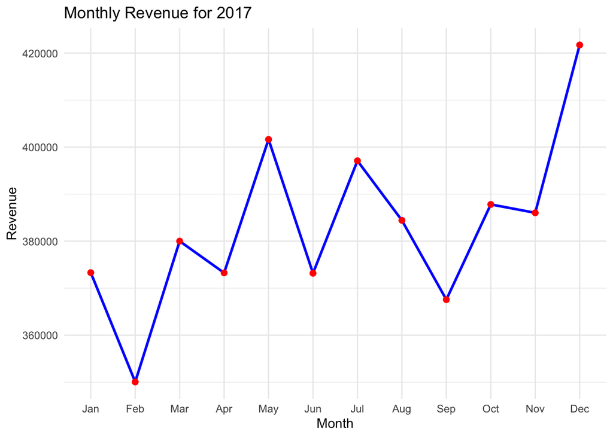

```r
monthly_revenue <- transactions %>%
  filter(year(transaction_timestamp) == 2017) %>%
  mutate(month = factor(month(transaction_timestamp, label = TRUE, abbr = TRUE), levels = month.abb)) %>%
  group_by(month) %>%
  summarise(monthly_revenue = sum(sales_value, na.rm = TRUE))

ggplot(monthly_revenue, aes(x = month, y = monthly_revenue, group = 1)) +
  geom_line(color = "blue", size = 1) +
  geom_point(color = "red", size = 2) +
  labs(
    title = "Monthly Revenue for 2017",
    x = "Month",
    y = "Revenue"
  ) +
  theme_minimal()
```

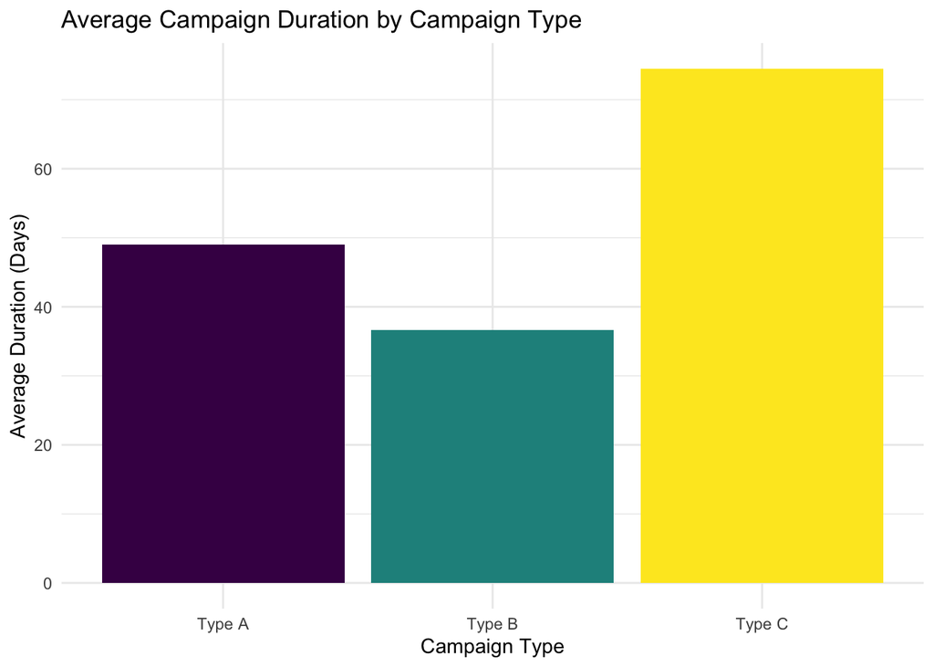

```r
average_duration_by_type <- campaign_descriptions %>%
  mutate(
    start_date = as.Date(start_date),
    end_date = as.Date(end_date),
    duration_days = as.numeric(difftime(end_date, start_date, units = "days"))
  ) %>%
  select(campaign_id, campaign_type, duration_days) %>%
  arrange(campaign_type, campaign_id) %>%
  group_by(campaign_type) %>%
  summarise(
    average_duration = mean(duration_days),
    campaign_count = n()
  )



ggplot(average_duration_by_type, aes(x = campaign_type, y = average_duration, fill = campaign_type)) +
  geom_bar(stat = "identity") +
  labs(
    title = "Average Campaign Duration by Campaign Type",
    x = "Campaign Type",
    y = "Average Duration (Days)"
  ) +
  theme_minimal() +
  theme(legend.position = "none")
```

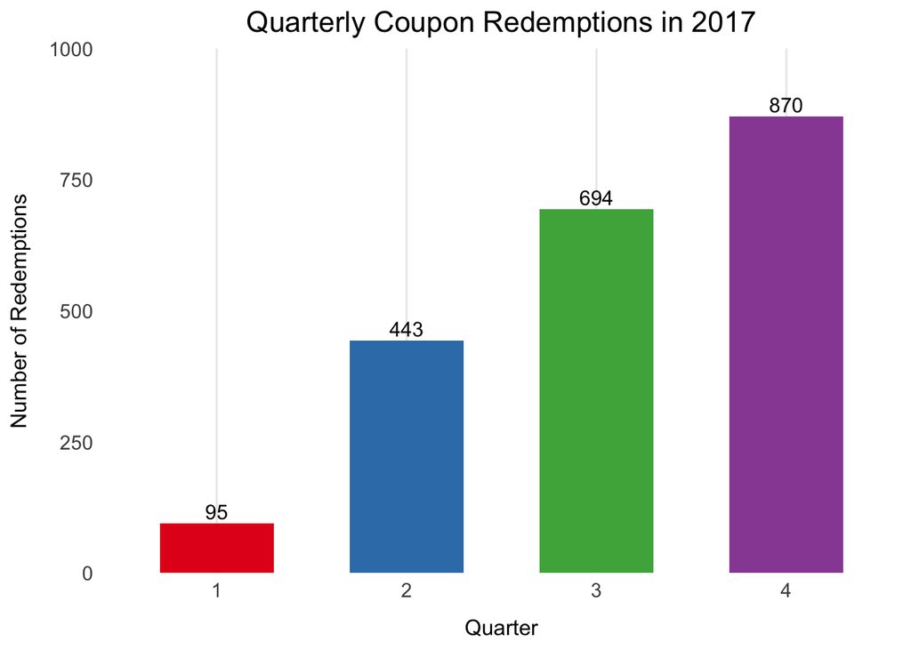

```r
quarterly_redemptions <- coupon_redemptions %>%
  mutate(redemption_date = as.Date(redemption_date)) %>%
  filter(year(redemption_date) == 2017) %>%
  mutate(quarter = quarter(redemption_date)) %>%
  group_by(quarter) %>%
  summarise(total_redemptions = n(), .groups = 'drop')

ggplot(quarterly_redemptions, aes(x = factor(quarter), y = total_redemptions, fill = factor(quarter))) +
  geom_bar(stat = "identity", show.legend = FALSE, width = 0.6) +
  geom_text(aes(label = total_redemptions), vjust = -0.3, size = 4, color = "black") +
  scale_y_continuous(expand = expansion(mult = c(0, 0.15))) +
  labs(
    title = "Quarterly Coupon Redemptions in 2017",
    x = "Quarter",
    y = "Number of Redemptions"
  ) +
  theme_minimal(base_size = 12) +
  theme(
    plot.title = element_text(size = 16, hjust = 0.5),
    axis.title.y = element_text(margin = margin(r = 10)),
    axis.title.x = element_text(margin = margin(t = 10)),
    axis.text = element_text(size = 11),
    panel.grid.major.y = element_blank(),
    panel.grid.minor = element_blank()
  ) +
  scale_fill_brewer(palette = "Set1")
```

##### This graph illustrates the quarterly coupon redemptions for 2017. The data shows that the last quarter had the highest redemption rates, while the first quarter recorded the lowest. It appears that the frequent campaigns contributed to an increase in coupon redemptions, capturing customers’ attention and subsequently boosting foot traffic.

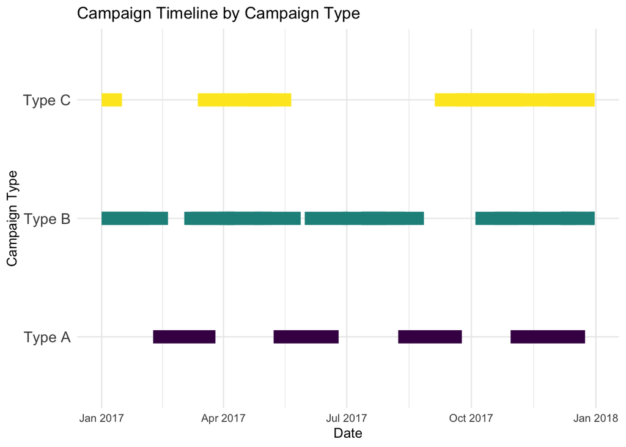

```r
campaigns_timeline <- campaign_descriptions %>%
  mutate(
    start_date = as.Date(start_date),
    end_date = as.Date(end_date),
    campaign_type = as.factor(campaign_type)
  ) %>%
  filter(
    start_date <= as.Date("2017-12-31") & end_date >= as.Date("2017-01-01")
  ) %>%
  mutate(
    start_date = pmax(start_date, as.Date("2017-01-01")),
    end_date = pmin(end_date, as.Date("2017-12-31"))
  )

ggplot(campaigns_timeline, aes(x = start_date, y = campaign_type)) +
  geom_segment(aes(xend = end_date, yend = campaign_type, color = campaign_type), size = 5) +
  labs(
    title = "Campaign Timeline by Campaign Type",
    x = "Date",
    y = "Campaign Type",
    color = "Campaign Type"
  ) +
  theme_minimal() +
  theme(
    axis.text.y = element_text(size = 12),
    legend.position = "none"
  )
```

##### This graph illustrates the timeline for campaigns of Type A, Type B, and Type C. The Type A campaign exhibits nearly consistent intervals and durations, while Type B and Type C campaigns are non-targeted and display irregular intervals and durations. This suggests that the Type A campaigns were strategically planned with a clear promotional intention. Conversely, the Type B and Type C campaigns appear to have been conducted at random intervals, lacking specific targets or objectives.

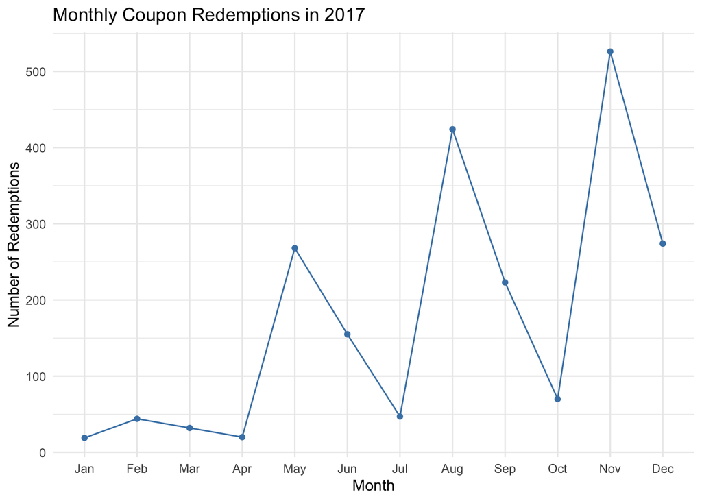

```r
coupon_redemptions %>%
  mutate(redemption_date = as.Date(redemption_date)) %>%
  filter(year(redemption_date) == 2017) %>%
  mutate(month = factor(month(redemption_date, label = TRUE, abbr = TRUE), levels = month.abb)) %>%
  count(month) %>%
  ggplot(aes(x = month, y = n, group = 1)) +
  geom_line(color = "steelblue") +
  geom_point(color = "steelblue") +
  labs(
    title = "Monthly Coupon Redemptions in 2017",
    x = "Month",
    y = "Number of Redemptions"
  ) +
  theme_minimal()
```

##### This graph illustrates the monthly coupon redemptions over the year. We observe that during the first quarter, there were few coupon redemptions. However, after April, the number of redemptions began to rise. Notably, there were significant declines in July, October, and December. Overall, coupon redemptions have increased over time.

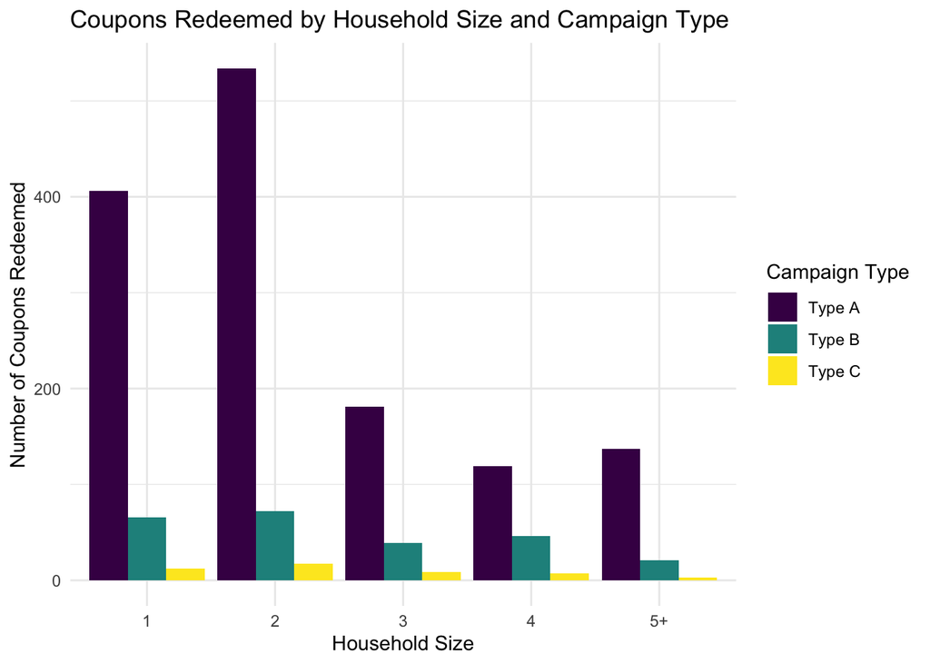

```r
redemptions_by_size_and_type <- coupon_redemptions %>%
  inner_join(campaign_descriptions, by = "campaign_id") %>%
  inner_join(demographics, by = "household_id") %>%
  group_by(household_size, campaign_type) %>%
  summarise(coupons_redeemed = n()) %>%
  ungroup()

ggplot(redemptions_by_size_and_type, aes(x = household_size, y = coupons_redeemed, fill = campaign_type)) +
  geom_bar(stat = "identity", position = "dodge") +
  labs(
    title = "Coupons Redeemed by Household Size and Campaign Type",
    x = "Household Size",
    y = "Number of Coupons Redeemed",
    fill = "Campaign Type"
  ) +
  theme_minimal()
```

##### This graph shows that Type A coupons are the most frequently used, while Type B coupons have moderate usage, and Type C coupons are used very little. For households of size 1 and 2, the majority of coupon usage comes from Type A, particularly for households of size 2. It appears that the targeted group for the Type A campaign was primarily households of size 1 and 2.

```r
coupons_by_income <- coupon_redemptions %>%
  inner_join(demographics, by = "household_id") %>%
  group_by(income) %>%
  summarise(
    coupons_redeemed = n(),
    .groups = "drop"
  ) %>%
  ungroup()

coupons_by_income <- coupons_by_income %>%
  mutate(
    income_order = sapply(income, function(income_str) {
      income_str_clean <- gsub("[$,K]", "", income_str)
      if (grepl("^Under", income_str_clean)) {
        return(0)
      } else if (grepl("^Over", income_str_clean)) {
        lower_bound <- as.numeric(str_extract(income_str_clean, "[0-9]+"))
        return(lower_bound)
      } else {
        lower_bound <- as.numeric(str_extract(income_str_clean, "^[0-9]+"))
        return(lower_bound)
      }
    })
  ) %>%
  arrange(income_order) %>%
  mutate(income = factor(income, levels = unique(income)))

coupons_by_income <- coupons_by_income %>%
  mutate(percentage = coupons_redeemed / sum(coupons_redeemed))

print(coupons_by_income)
```

```
## # A tibble: 12 × 4
##    income    coupons_redeemed income_order percentage
##    <ord>                <int>        <dbl>      <dbl>
##  1 Under 15K              104            0    0.0623
##  2 15-24K                  75           15    0.0449
##  3 25-34K                 129           25    0.0773
##  4 35-49K                 234           35    0.140
##  5 50-74K                 593           50    0.355
##  6 75-99K                 247           75    0.148
##  7 100-124K                46          100    0.0276
##  8 125-149K                98          125    0.0587
##  9 150-174K               115          150    0.0689
## 10 175-199K                21          175    0.0126
## 11 200-249K                 4          200    0.00240
## 12 250K+                    3          250    0.00180
```

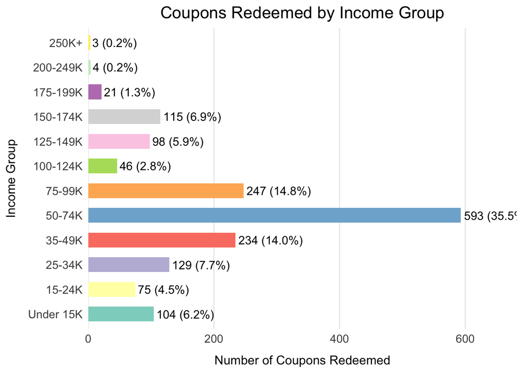

```r
ggplot(coupons_by_income, aes(x = coupons_redeemed, y = income, fill = income)) +
  geom_bar(stat = "identity", show.legend = FALSE, width = 0.6) +
  geom_text(
    aes(label = paste0(coupons_redeemed, " (", scales::percent(percentage, accuracy = 0.1), ")")),
    hjust = -0.05, size = 4, color = "black"
  ) +
  scale_x_continuous(expand = expansion(mult = c(0, 0.15))) +
  labs(
    title = "Coupons Redeemed by Income Group",
    x = "Number of Coupons Redeemed",
    y = "Income Group"
  ) +
  theme_minimal(base_size = 12) +
  theme(
    plot.title = element_text(size = 16, hjust = 0.5),
    axis.title.y = element_text(margin = margin(r = 10)),
    axis.title.x = element_text(margin = margin(t = 10)),
    axis.text = element_text(size = 11),
    panel.grid.major.y = element_blank(),
    panel.grid.minor = element_blank()
  ) +
  scale_fill_brewer(palette = "Set3")
```

##### This graph represents the percentage of coupons redeemed by income group along with the number of coupons redeemed. We see that the income group 50-74K redeemed 593 coupons i.e., 35.5%. The lowest number of coupons that were redeemed were by 200-249K and 250K+ income groups. Also, we noticed that the income groups 175-199K and100-124K have used a lesser number of coupons. From this graph, we understand that even though the 50-70K income group is the highest group for redemption but the percentage difference from the other income groups are large.

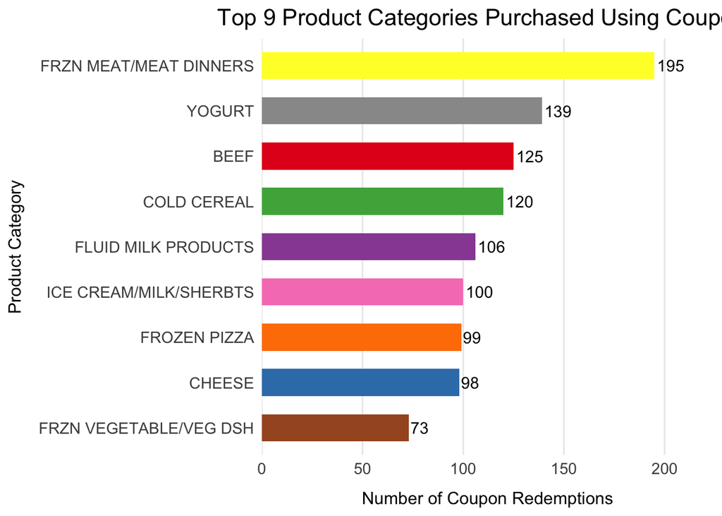

```r
top_9_categories <- coupon_redemptions %>%
  inner_join(coupons, by = c("coupon_upc", "campaign_id")) %>%
  mutate(redemption_date = as.Date(redemption_date)) %>%
  inner_join(transactions %>% mutate(transaction_date = as.Date(transaction_timestamp)),
             by = c("household_id", "product_id")) %>%
  filter(redemption_date == transaction_date) %>%
  inner_join(products, by = "product_id") %>%
  group_by(product_category) %>%
  summarise(coupon_redemptions = n(), .groups = 'drop') %>%
  arrange(desc(coupon_redemptions)) %>%
  slice_head(n = 9)

ggplot(top_9_categories, aes(x = reorder(product_category, coupon_redemptions), y = coupon_redemptions, fill = product_category)) +
  geom_bar(stat = "identity", show.legend = FALSE, width = 0.6) +
  geom_text(aes(label = coupon_redemptions), hjust = -0.1, size = 4, color = "black") +
  coord_flip() +
  scale_x_discrete() +
  scale_y_continuous(expand = expansion(mult = c(0, 0.15))) +
  labs(
    title = "Top 9 Product Categories Purchased Using Coupons",
    x = "Product Category",
    y = "Number of Coupon Redemptions"
  ) +
  theme_minimal(base_size = 12) +
  theme(
    plot.title = element_text(size = 16, hjust = 0.5),
    axis.title.y = element_text(margin = margin(r = 10)),
    axis.title.x = element_text(margin = margin(t = 10)),
    axis.text = element_text(size = 11),
    panel.grid.major.y = element_blank(),
    panel.grid.minor = element_blank()
  ) +
  scale_fill_brewer(palette = "Set1")
```

##### This graph displays the top nine product categories purchased with coupons, with Frozen Meat/Meat Dinners leading the list, followed by Yogurt, Beef, Cold Cereal, Fluid Milk Products, Ice Cream/Milk/Sherbets, Frozen Pizza, Cheese, and Frozen Vegetables/Vegetable Dishes. This trend indicates that customers are most inclined to use coupons for frozen foods, dairy products, and breakfast items. By understanding these preferences, we can strategically create coupons for these popular categories to further enhance sales, particularly focusing on frozen meat and other high-demand products.

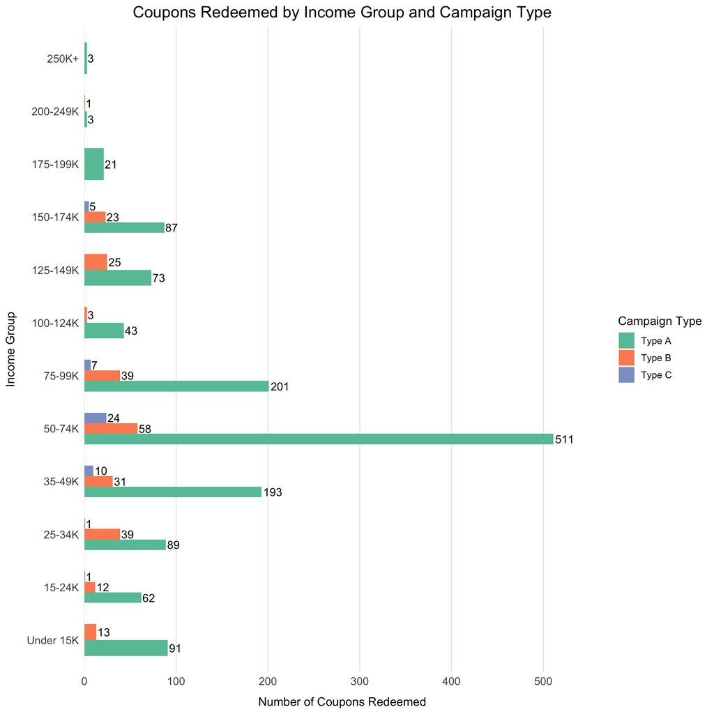

```r
campaigns_by_income <- coupon_redemptions %>%
  inner_join(campaign_descriptions, by = "campaign_id") %>%
  inner_join(demographics, by = "household_id") %>%
  mutate(income_order = as.numeric(str_extract(gsub("[$,]", "", income), "^[0-9]+"))) %>%
  group_by(campaign_type, income) %>%
  summarise(coupons_redeemed = n(), .groups = 'drop') %>%
  arrange(campaign_type, income) %>%
  mutate(income = factor(income, levels = unique(income), ordered = TRUE))

# Plot the data
ggplot(campaigns_by_income, aes(x = coupons_redeemed, y = income, fill = campaign_type)) +
  geom_bar(stat = "identity", position = "dodge", width = 0.6) +
  geom_text(aes(label = coupons_redeemed), hjust = -0.1, size = 4, color = "black", position = position_dodge(width = 0.6)) +
  scale_x_continuous(expand = expansion(mult = c(0, 0.1))) +
  labs(
    title = "Coupons Redeemed by Income Group and Campaign Type",
    x = "Number of Coupons Redeemed",
    y = "Income Group",
    fill = "Campaign Type"
  ) +
  theme_minimal(base_size = 12) +
  theme(
    plot.title = element_text(size = 16, hjust = 0.5),
    axis.title.y = element_text(margin = margin(r = 10)),
    axis.title.x = element_text(margin = margin(t = 10)),
    axis.text = element_text(size = 11),
    panel.grid.major.y = element_blank(),
    panel.grid.minor = element_blank()
  ) +
  scale_fill_brewer(palette = "Set2")
```

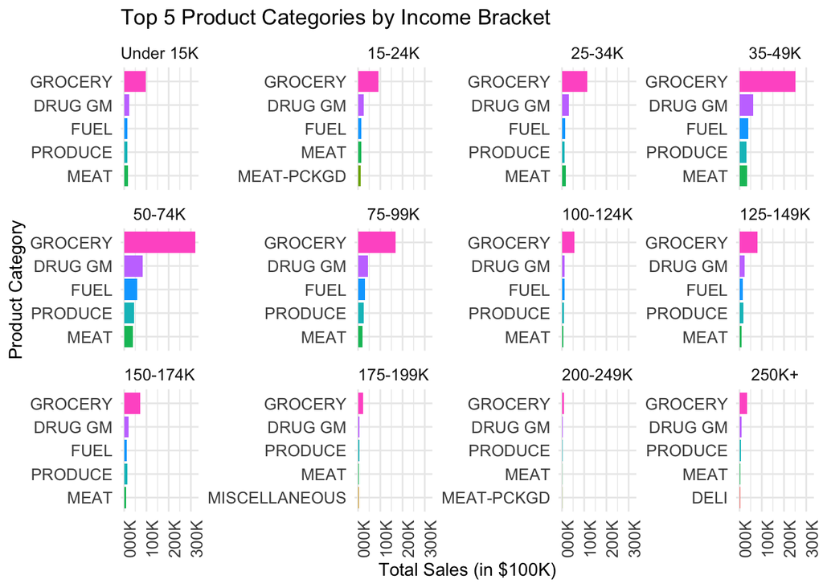

```r
top_5_categories_by_income <- transactions %>%
  left_join(products, by = "product_id") %>%
  left_join(demographics, by = "household_id") %>%
  filter(!is.na(income), !is.na(department)) %>%
  group_by(income, department) %>%
  summarise(total_sales = sum(sales_value, na.rm = TRUE), .groups = 'drop') %>%
  arrange(desc(total_sales)) %>%
  slice_head(n = 5, by = income) %>%
  mutate(department = reorder(department, total_sales))

ggplot(top_5_categories_by_income, aes(x = department, y = total_sales / 100000, fill = department)) +
  geom_col(show.legend = FALSE) +
  facet_wrap(~ income, scales = "free_y") +
  labs(
    title = "Top 5 Product Categories by Income Bracket",
    x = "Product Category",
    y = "Total Sales (in $100K)"
  ) +
  coord_flip() +
  scale_y_continuous(labels = scales::label_number(suffix = "00K")) +
  theme_minimal() +
  theme(
    strip.text = element_text(size = 10),
    axis.text.y = element_text(size = 10),
    axis.text.x = element_text(size = 10, angle = 90)
  )
```

# Summary

##### Based on our analysis, we recommend expanding the Type A campaign to other demographics, optimizing the focus and duration of Type B and C, and creating new strategies to engage higher-income households. These adjustments could significantly enhance Regork’s marketing efficiency and drive higher revenue.

##### However, limitations such as the small sample size, lack of campaign detail, and short timeframe suggest that future efforts should include more extensive data collection and longer-term trend analysis to create a more robust strategy.